# A-prioi comparisons with contrasts

Laurel Brehm

# How to use contrasts efficiently to get the comparisons you want

I simulated some data that would work for this example using lexdec, making up some data for how native language might affect lexical decision time. Use this data (which has a 4-level variable) to show how different contrast coding schemes provide different a-priori comparisons in your data.

We will use a centered Frequency variable because it makes the other effects a little easier to see– centering a continuous variable is a nice trick to make the model converge a little faster too (but at the expense of naive readability as to what zero reflects).

Load in data, center frequency, and make a boxplot.

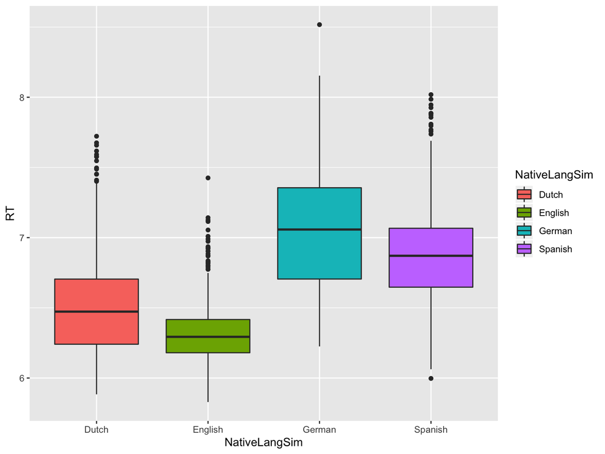

```r
lexdecSm <- read.table('simulatedLexDec.txt',header=T)

lexdecSm$FreqC <- lexdecSm$Frequency - mean(lexdecSm$Frequency)

### make a boxplot of means
## (note that Dutch is the leftmost-- alphabetical assignment)
ggplot(lexdecSm,aes(x=NativeLangSim,y=RT,fill=NativeLangSim))+
  geom_boxplot()
```

# How to use contrasts efficiently to get the comparisons you want

I made up this example to have the default contrast coding scheme be useless– it would compare all levels to the first-alphabetically, which is Dutch. Let’s try some different contrasts instead.

```r
contrasts(lexdecSm$NativeLangSim)
```

```
##         English German Spanish
## Dutch         0      0       0
## English       1      0       0
## German        0      1       0
## Spanish       0      0       1
```

# Sum contrasts

Let’s use a sum coding contrast scheme: Compare Dutch to English, German to Spanish, and the average of English and Dutch to the average of German and Spanish. This will allow us to test whether the most-similar language is different from English, and whether the two most-different languages are different from each other. Set these, and run a new analysis.

To run this, we will make it so that zero lives in the middle of each of our comparisons, by making them positive and negative 1/2.

```r
## make new contrast matrix with named values
## my own personal convention = label has positive value first
EngvDutch <- c(-1/2,1/2,0,0)  ## Dutch = -1/2, Eng = 1/2
GervSpa <- c(0,0,1/2,-1/2) ## Ger = 1/2, Spa = -1/2
EngDuvGerSpa <- c(1/2,1/2,-1/2,-1/2) ## Dutch = 1/2, Eng= 1/2, Ger=-1/2 Spa=-1/2

SumZero <- cbind(EngvDutch,GervSpa,EngDuvGerSpa)
rownames(SumZero)=c("Dutch","English","German","Spanish")

## set these contrasts
contrasts(lexdecSm$NativeLangSim) <- SumZero

### run analysis
lmSumZero <- lmer(RT~NativeLangSim*FreqC + (1+FreqC|Subject)+(1 |Word),data=lexdecSm)
summary(lmSumZero)
```

```
## Linear mixed model fit by REML ['lmerMod']
## Formula: RT ~ NativeLangSim * FreqC + (1 + FreqC | Subject) + (1 | Word)
##    Data: lexdecSm
##
## REML criterion at convergence: -2706.5
##
## Scaled residuals:
##     Min      1Q  Median      3Q     Max
## -2.6598 -0.6337 -0.0588  0.5119  6.4533
##
## Random effects:
##  Groups   Name        Variance  Std.Dev. Corr
##  Word     (Intercept) 0.0077980 0.08831
##  Subject  (Intercept) 0.0860577 0.29336
##           FreqC       0.0004202 0.02050  -0.10
##  Residual             0.0279080 0.16706
## Number of obs: 4503, groups:  Word, 79; Subject, 57
##
## Fixed effects:
##                                  Estimate Std. Error t value
## (Intercept)                      6.685826   0.040360 165.656
## NativeLangSimEngvDutch          -0.197600   0.113849  -1.736
## NativeLangSimGervSpa             0.186675   0.107338   1.739
## NativeLangSimEngDuvGerSpa       -0.537433   0.078235  -6.869
## FreqC                           -0.050617   0.008488  -5.963
## NativeLangSimEngvDutch:FreqC     0.030800   0.009780   3.149
## NativeLangSimGervSpa:FreqC      -0.010095   0.009220  -1.095
## NativeLangSimEngDuvGerSpa:FreqC  0.008237   0.006720   1.226
##
## Correlation of Fixed Effects:
##             (Intr) NtLSED NtLSGS NtLSEDGS FreqC  NLSED: NLSGS:
## NtvLngSmEnD  0.078
## NtvLngSmGrS  0.000  0.000
## NtvLngSEDGS  0.057  0.081  0.000
## FreqC       -0.031 -0.003  0.000 -0.002
## NtvLnSED:FC -0.006 -0.081  0.000 -0.007    0.032
## NtvLnSGS:FC  0.000  0.000 -0.081  0.000    0.000  0.000
## NtLSEDGS:FC -0.005 -0.007  0.000 -0.081    0.023  0.081  0.000
```

# Sum contrasts

And, there is an EngDu by Frequency interaction. This means that the red line has a steeper slope than the green line in the left panel… steeper by beta (0.03) much.

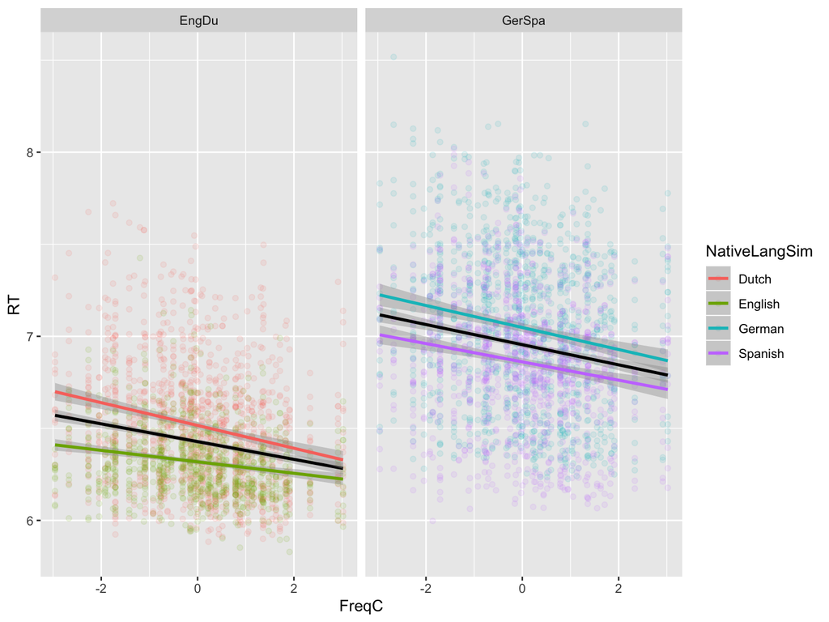

```r
### plot to unpack interaction!
## use revalue function from plyr package to make new var that sets up contrast we want in display
lexdecSm$NLcontr3 <- plyr::revalue(lexdecSm$NativeLangSim,c("English"="EngDu","Dutch"="EngDu","German"="GerSpa","Spanish"="GerSpa"))

ggplot(lexdecSm,aes(x=FreqC,y=RT,color=NativeLangSim))+
  geom_point(alpha=.1) + geom_smooth(color='black',method='lm') +
  geom_smooth(method='lm') + facet_grid(~NLcontr3)
```

# Simple effect contrasts

A contrast coding scheme that tests effects with respect to the average level is called simple effects coding. This is also straighforward to implement. It’s like the dummy coding matrix (which was ones and zeroes), but instead of zeroes, we use -1/k (here, -1/4). Instead of ones, we use (k-1)/k.

```r
#### Set simple effects coding contrasts ####
### reference level = still English
## make new contrast matrix with named values
Dutch <- c(3/4,-1/4,-1/4,-1/4)
Ger <- c(-1/4,-1/4,3/4,-1/4)
Spa <- c(-1/4,-1/4,-1/4,3/4)

Seff <- cbind(Dutch,Ger,Spa)
rownames(Seff)=c("Dutch","English","German","Spanish")

## set these contrasts
contrasts(lexdecSm$NativeLangSim) <- Seff

### run analysis
lmSimple <- lmer(RT~NativeLangSim*FreqC + (1+FreqC|Subject)+(1|Word),data=lexdecSm)
```

# Simple effects contrasts

This is key: contrasts affect the other variables too, since they affect what the intercept means. Make sure to set the right contrasts for comparing ALL variables at the right level.

```r
summary(lmSimple)
```

```
## Linear mixed model fit by REML ['lmerMod']
## Formula: RT ~ NativeLangSim * FreqC + (1 + FreqC | Subject) + (1 | Word)
##    Data: lexdecSm
##
## REML criterion at convergence: -2706.5
##
## Scaled residuals:
##     Min      1Q  Median      3Q     Max
## -2.6598 -0.6337 -0.0588  0.5119  6.4533
##
## Random effects:
##  Groups   Name        Variance  Std.Dev. Corr
##  Word     (Intercept) 0.0077978 0.08831
##  Subject  (Intercept) 0.0860570 0.29335
##           FreqC       0.0004202 0.02050  -0.10
##  Residual             0.0279080 0.16706
## Number of obs: 4503, groups:  Word, 79; Subject, 57
##
## Fixed effects:
##                           Estimate Std. Error t value
## (Intercept)               6.685826   0.040359 165.657
## NativeLangSimDutch        0.197600   0.113849   1.736
## NativeLangSimGer          0.729571   0.113849   6.408
## NativeLangSimSpa          0.542896   0.113849   4.769
## FreqC                    -0.050617   0.008488  -5.963
## NativeLangSimDutch:FreqC -0.030800   0.009780  -3.149
## NativeLangSimGer:FreqC   -0.028684   0.009780  -2.933
## NativeLangSimSpa:FreqC   -0.018589   0.009780  -1.901
##
## Correlation of Fixed Effects:
##             (Intr) NtvLSD NtvLSG NtvLSS FreqC  NLSD:F NLSG:F
## NtvLngSmDtc -0.078
## NatvLngSmGr -0.078  0.556
## NatvLngSmSp -0.078  0.556  0.556
## FreqC       -0.031  0.003  0.003  0.003
## NtvLngSD:FC  0.006 -0.081 -0.045 -0.045 -0.032
## NtvLngSG:FC  0.006 -0.045 -0.081 -0.045 -0.032  0.556
## NtvLngSS:FC  0.006 -0.045 -0.045 -0.081 -0.032  0.556  0.556
```

# Helmert contrasts

A variant on sum coding is Helmert coding. This is useful for ordered factors. Here, the first comparison tests one level versus everything ‘larger’ than it (ordinally), by comparing (k-1) to -1. The second comparsion replaces the (k-1) with a zero, and then compares the next largest level to everything ‘larger’, by setting those to -1. And so forth, until you’re only comparing two things!

```r
## make new contrast matrix with named values
## remember, the levels are out of order!
H1 <- c(-1,3,-1,-1)
H2 <- c(2,0,-1,-1)
H3 <- c(0,0,1,-1)

Helm <- cbind(H1,H2,H3)
rownames(Helm)=c("Dutch","English","German","Spanish")

#set contrasts
contrasts(lexdecSm$NativeLangSim) <- Helm

## if you have things ordered in the right way, this is equivalent to
#contrasts(lexdecSm$NativeLangSim) <- contr.helmert

### run analysis
lmHelm <- lmer(RT~NativeLangSim*FreqC + (1+FreqC|Subject)+(1 |Word),data=lexdecSm)
```

# Helmert contrasts

The intercept is the same as in the sum coding model and the simple effects model; same for the main effect of frequency. The main effects at each contrast are different. Contrast 1 reflects the difference between the English RT and everything else; contrast 2 reflects Dutch vs German and Spanish; and contrast 3 reflects German vs Spanish.

But! They don’t reflect the numeric difference. They reflect the average difference in the levels compared. This says that the average difference between English and all others is roughly the same as Dutch and (Spanish, German), but that the Spanish-German difference is smaller.

What’s particularly nice about this model is the way we can interpret the interactions. Note that the estimate for contrast 1 by frequency is the largest– that reflects how English has a flatter slope for Frequency than all the other groups. (We saw that in the panel plot above!)

```r
summary(lmHelm)
```

```
## Linear mixed model fit by REML ['lmerMod']
## Formula: RT ~ NativeLangSim * FreqC + (1 + FreqC | Subject) + (1 | Word)
##    Data: lexdecSm
##
## REML criterion at convergence: -2693.8
##
## Scaled residuals:
##     Min      1Q  Median      3Q     Max
## -2.6598 -0.6337 -0.0588  0.5119  6.4533
##
## Random effects:
##  Groups   Name        Variance  Std.Dev. Corr
##  Word     (Intercept) 0.0077978 0.08831
##  Subject  (Intercept) 0.0860564 0.29335
##           FreqC       0.0004202 0.02050  -0.10
##  Residual             0.0279080 0.16706
## Number of obs: 4503, groups:  Word, 79; Subject, 57
##
## Fixed effects:
##                        Estimate Std. Error t value
## (Intercept)            6.685826   0.040359 165.657
## NativeLangSimH1       -0.122506   0.023876  -5.131
## NativeLangSimH2       -0.146211   0.030986  -4.719
## NativeLangSimH3        0.093337   0.053669   1.739
## FreqC                 -0.050617   0.008488  -5.963
## NativeLangSimH1:FreqC  0.006506   0.002051   3.172
## NativeLangSimH2:FreqC -0.002388   0.002662  -0.897
## NativeLangSimH3:FreqC -0.005047   0.004610  -1.095
##
## Correlation of Fixed Effects:
##             (Intr) NtLSH1 NtLSH2 NtLSH3 FreqC  NLSH1: NLSH2:
## NatvLngSmH1  0.093
## NatvLngSmH2  0.000  0.000
## NatvLngSmH3  0.000  0.000  0.000
## FreqC       -0.031 -0.003  0.000  0.000
## NtvLnSH1:FC -0.008 -0.081  0.000  0.000  0.038
## NtvLnSH2:FC  0.000  0.000 -0.081  0.000  0.000  0.000
## NtvLnSH3:FC  0.000  0.000  0.000 -0.081  0.000  0.000  0.000
```

# More fun with contrasts

To learn more:

Setting your own contrasts in R: https://stats.idre.ucla.edu/r/library/r-library-contrast-coding-systems-for-categorical-variables/

Using built-ins effectively: https://arxiv.org/abs/1807.10451